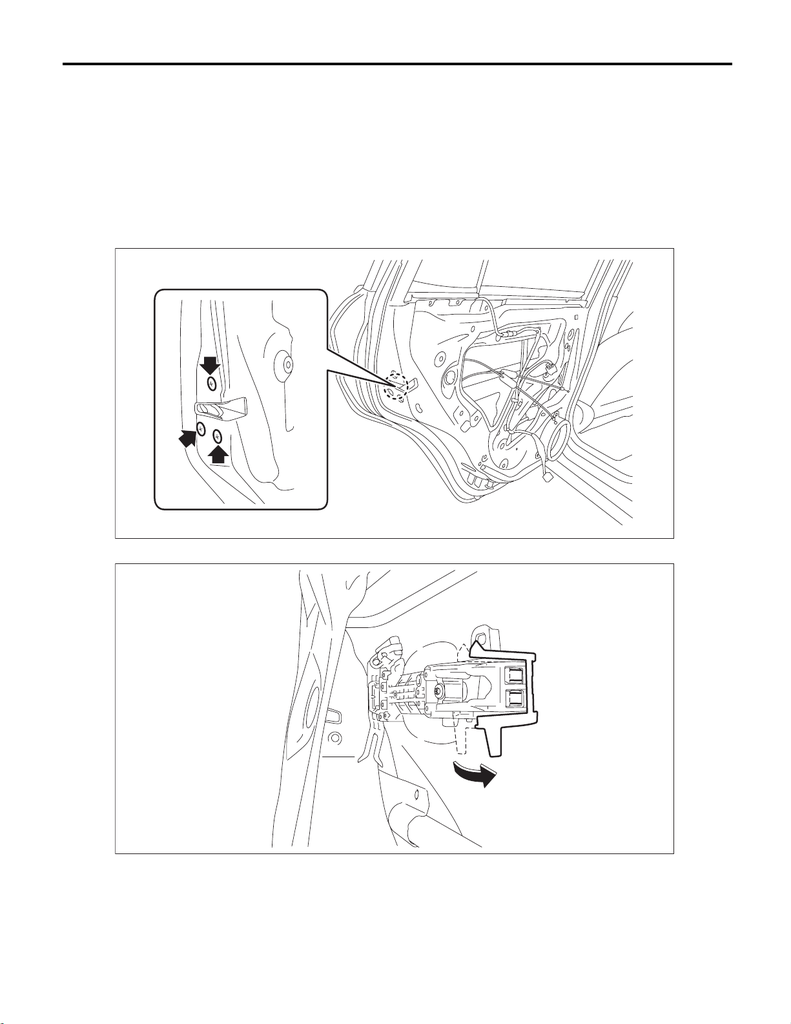

SL-41

Rear Outer Handle

SECURITY AND LOCKS

12.Rear Outer Handle

A: REMOVAL

1) Raise the glass assembly - rear door to the top position.

2) Disconnect the ground cable from battery. <Ref. to NT-5, BATTERY, NOTE, Note.>

NOTE:

For models other than STI model, disconnect the ground terminal from battery sensor.

3) Remove the trim panel - rear door. <Ref. to EI-57, REAR DOOR, REMOVAL, Door Trim.>

4) Remove the sealing cover - rear door. <Ref. to EB-41, REMOVAL, Rear Sealing Cover.>

5) Remove the screws and move downward the latch & actuator assembly - rear.

6) Remove the holder of the frame assembly - rear door outer.

SL-02862

SL-01452

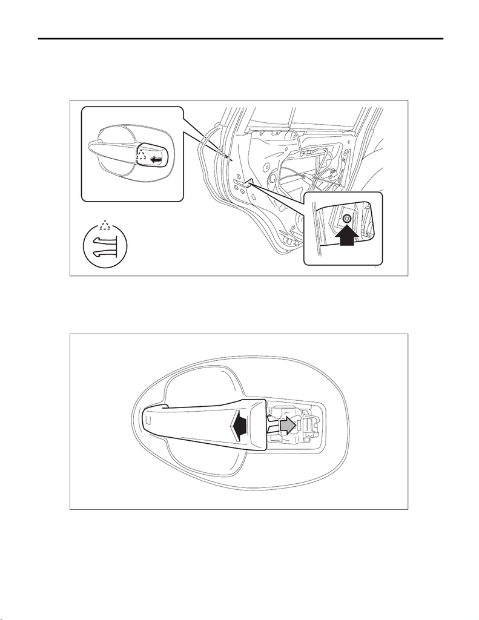

SL-42

Rear Outer Handle

SECURITY AND LOCKS

7) Remove the cover - handle rear outer.

Preparation tool:

TORX

®

T30

(1) Loosen the TORX

®

bolt.

(2) Release the claws, and then remove the cover - handle rear outer.

8) Remove the handle - door outer.

CAUTION:

(2) Pull the handle - door outer towards yourself to remove the handle - door outer.

SL-02863

SL-01182

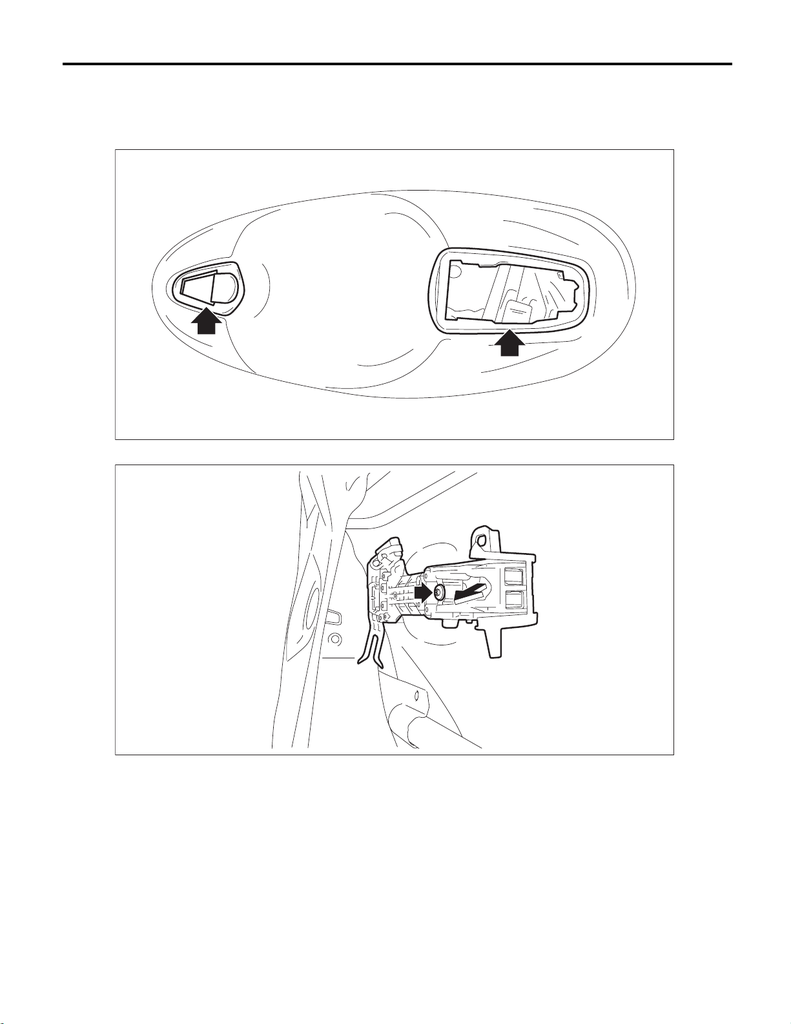

SL-43

Rear Outer Handle

SECURITY AND LOCKS

9) Remove the frame assembly - rear door outer.

Preparation tool:

TORX

®

T30

(1) Remove the spacer - door handle outer.

(2) Loosen the TORX

®

bolt and remove the frame assembly - rear door outer.

SL-01177

SL-01455

[figure not shown]

SL-44

Rear Outer Handle

SECURITY AND LOCKS

B: INSTALLATION

1) Before installation, check the following items.

• Lever is free from deformation.

• Grease is applied sufficiently to lever joints.

If grease is insufficient, add it as necessary before assembling.

2) Install the frame assembly - rear door outer.

Preparation tool:

TORX

®

T30

Tightening torque:

7.5 N·m (0.8 kgf-m, 5.5 ft-lb)

3) Install the spacer - door handle outer.

4) Install the handle - door outer.

(1) Insert the end of the handle - door outer to the frame assembly - rear door outer.

(2) Push forward while inserting the rear end of the handle - door outer to the frame assembly - rear door

outer.

5) Install the cover - handle rear outer.

Preparation tool:

TORX

®

T30

Tightening torque:

7.5 N·m (0.8 kgf-m, 5.5 ft-lb)

6) Install the latch and actuator assembly - rear.

Tightening torque:

6.5 N·m (0.7 kgf-m, 5.2 ft-lb)

7) Install the sealing cover - rear door.

8) Install the trim panel - rear door.

9) Connect the battery ground terminal. <Ref. to NT-5, BATTERY, NOTE, Note.>

NOTE:

For models other than STI model, connect the ground terminal to battery sensor.

C: INSPECTION

Check if the outer handle operates normally.

If the lever is faulty, replace the handle - door outer.